# Grym Fundamentals

S. Wotherspoon & D. Maschette

January 2022

## Introduction

Grym is a fisheries stock projection model that reproduces and extends the core functionality of the Generalized Yield Model (GYM) described in Constable and de la Mare (1996). Grym is an age structured, non-spatially explicit, single stock projection model. Grim is not an estimation model - it does not estimate parameters describing the fishery from input data, any parameters describing the behaviour of the fishery must be estimated through some external process and provided to Grym directly.

This document provides a tutorial introduction to the basic features provide by Grym. We assume that the Grym is installed and loaded.

```r
library(Grym)
```

## Basic Model

The original GYM projects stock abundance, biomass and yield forward over time by integrating a system of differential equations with an adaptive Runge-Kutta scheme. The GYM assumes the number $N_{a,y}$, biomass $B_{a,y}$ and yield $Y_{a,y}$ of individuals of age $a$ in year $y$ satisfy the system of differential equations (Constable and de la Mare 1996)
$$\begin{align}
\frac{dN_{a,y}}{dt} &= - \Big [ M_{y} m(a,t,y) + F_{y} f(a,t,y) \Big ] N_{a,y}\\
\frac{dB_{a,y}}{dt} &= w(a+t)\frac{dN_{a,y}}{dt} + N_{a,y}(t) \frac{dw(a+t)}{dt}\\
\frac{dY_{a,y}}{dt} &= F_{y} f(a,t,y) B_{a,y}
\end{align}$$
where $w(a+t)$ represents the weight at total age $a+t$, and the total natural mortality $M_{y} m(a,t,y)$ has been decomposed into an annually varying component $M_{y}$ and a component $m(a,t,y)$ that varies within years, and similarly the total fishing mortality $F_{y} f(a,t,y)$ has been decomposed into an annual component $F_{Y}$ and a component $f(a,t,y)$ that varies within years. The total yield in each year is the sum of the contributions from each age class
$$Y_{y} = \sum_{a} Y_{a,y}(1).$$

The GYM solves this system of differential equations for each year by assuming the time varying functions $m(a,t,y)$, $f(a,t,y)$ and $w(a+t)$ are piecewise linear, and integrating the system with an adaptive Runge-Kutta scheme.

Grym takes a more direct approach. The system of differential equations has solution
$$\begin{align}
N_{a,y}(t) &= N_{a,y}(0)\exp \left [ - M_{y} \int_{y}^{y+t} m(a,\tau,y) d \tau - F_{y} \int_{y}^{y+t}f(a,\tau,y) d \tau\right ]\\
B_{a,y}(t) &= w(a+t) N_{a,y}(t)\\
Y_{a,y}(t) &= \int_{y}^{y+t}F_{y}f(a,\tau,y)B_{a,y}(\tau) d \tau.
\end{align}$$
Grym uses this solution directly, evaluating the required integrals by the composite trapezoidal rule. If $m(a,t,y)$ and $f(a,t,y)$ are assumed piecewise linear, this yields exact solutions for $N_{a,y}$ and $B_{a,y}$.

## Time Steps and Age Classes

The model divides the stock into $m$ annual age classes. The age classes must be sequential, but there is no requirement that the first class corresponds to age zero - individuals are not necessarily recruited to the modelled stock at birth. The final age class may be a “plus” class representing an aggregation of the oldest age classes in the population. For example, if 5 age classes are modelled and recruits enter the modelled population at age 3 and the final age class is a “plus” class, the age classes would represent the age ranges 3-4, 4-5, 5-6, 6-7 and 7+.

Each year is divided into $n$ time steps, and the state of the stock is recorded at the $n+1$ time points bounding those time steps. For example, if the year is divided into 365 daily time steps, the state of the stock is recorded at 366 time points, with the first representing to midnight before the first day, the second representing midnight after the first day and so one, with the final time point representing the midnight on the final day of the year.

Recruitment is assumed to occur instantaneously, and years are aligned in time so that recruitment occurs at the start of the the first time step.

In the krill assessment, seven age classes are used, corresponding to age ranges 1-2, 2-3, 3-4, 4-5, 5-6, 6-7 and 7-8, and each year is modelled as 365 daily time steps. So the initial ages in each age class, and the time points through the year (in units of years) are

```r
## Age classes and time steps
nsteps <- 365
Ages <- 1:7
Days <- seq(0,1,length=nsteps+1)
```

So the ages at which the stock is modelled are

```r
## Ages for which computations are performed
ages <- outer(Days,Ages,FUN="+")
head(ages)
```

```
##          [,1]     [,2]     [,3]     [,4]     [,5]     [,6]     [,7]
## [1,] 1.000000 2.000000 3.000000 4.000000 5.000000 6.000000 7.000000
## [2,] 1.002740 2.002740 3.002740 4.002740 5.002740 6.002740 7.002740
## [3,] 1.005479 2.005479 3.005479 4.005479 5.005479 6.005479 7.005479
## [4,] 1.008219 2.008219 3.008219 4.008219 5.008219 6.008219 7.008219
## [5,] 1.010959 2.010959 3.010959 4.010959 5.010959 6.010959 7.010959
## [6,] 1.013699 2.013699 3.013699 4.013699 5.013699 6.013699 7.013699
```

This matrix acts as a table that gives the age of each age class at each time point in the year - each column corresponds to an age class, and each row a time point. More precisely `ages[i,j]` is the age of an individual in age class `j` at time point `i` (that is, the beginning of time step `i`). Note that last entry in the second column corresponds to individuals that are age 3 in the final instant of the current year, and the first entry in the third column corresponds to individuals that are age 3 at the first instant of the current year.

## Size

To allow the model to translate between number of individuals and biomass, the user must specify the weight of an individual at each modelled age. This is done by providing a matrix `ws` that has the same dimensions as the `ages` matrix. Again this matrix acts as a table that gives the weight of an individual for each age class and each time point in the year.

It is common to calculate weight at age by first calculating length at age, and then computing weight from length, and Grym provides several functions to facilitate this.

In the krill assessment, a punctuated von Bertalanffy growth model is used to estimate length at age, and then weight is determined from length through a simple power law.

The `vonBertalanffyRAL` function computes length at age using a standard von Bertalanffy model assuming growth is restricted to the fraction of the year from `f0` to `f1`. This produces a matrix of lengths that has the same dimensions as the `ages` matrix. Again this acts as table that gives the length of an individual for each age class and each time point in the year.

```r
## Table of length at age
ls <- vonBertalanffyRAL(ages,t0=0,K=0.48,Linf=60,f0=21/365,f1=135/365)
head(ls)
```

```
##        [,1]     [,2]     [,3]     [,4]     [,5]     [,6]     [,7]
## [1,] 22.873 37.02643 45.78433 51.20358 54.55692 56.63191 57.91588
## [2,] 22.873 37.02643 45.78433 51.20358 54.55692 56.63191 57.91588
## [3,] 22.873 37.02643 45.78433 51.20358 54.55692 56.63191 57.91588
## [4,] 22.873 37.02643 45.78433 51.20358 54.55692 56.63191 57.91588
## [5,] 22.873 37.02643 45.78433 51.20358 54.55692 56.63191 57.91588
## [6,] 22.873 37.02643 45.78433 51.20358 54.55692 56.63191 57.91588
```

Here von Bertalanffy growth occurs in the period from day 21 to day 135 of the year, and outside this period the length is assumed constant. The entry `ls[i,j]` give the length of an individual in age class `j` at time point `i`.

We can visualize the growth pattern by plotting `ls` against `ages`

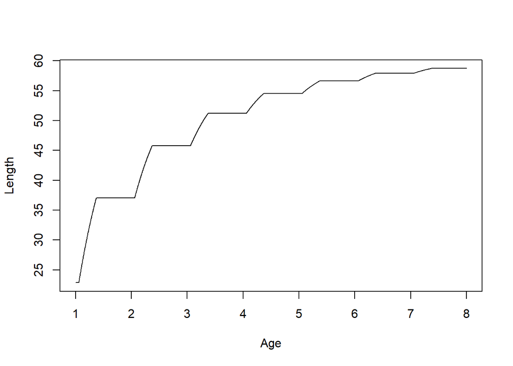

```r
## Plot length at age
plot(ages,ls,type="l",xlab="Age",ylab="Length")
```

The `powerLW` function computes weight from lengths using a standard power law. This produces a matrix that has the same dimensions as the `ages` and `ls` matrices, that tabulates the weight of an individual for each age class and each time point in the year.

```r
## Table of weight at age
ws <- powerLW(ls,a=0.000004,b=3.2)
head(ws)
```

```
##            [,1]      [,2]      [,3]     [,4]     [,5]     [,6]     [,7]
## [1,] 0.08951458 0.4181169 0.8248103 1.179835 1.445372 1.628756 1.749897
## [2,] 0.08951458 0.4181169 0.8248103 1.179835 1.445372 1.628756 1.749897
## [3,] 0.08951458 0.4181169 0.8248103 1.179835 1.445372 1.628756 1.749897
## [4,] 0.08951458 0.4181169 0.8248103 1.179835 1.445372 1.628756 1.749897
## [5,] 0.08951458 0.4181169 0.8248103 1.179835 1.445372 1.628756 1.749897
## [6,] 0.08951458 0.4181169 0.8248103 1.179835 1.445372 1.628756 1.749897
```

Again the entry `ws[i,j]` is the weight of an individual in age class `j` at time point `i`.

Plotting `ws` against `ls` shows a typical power law relationship

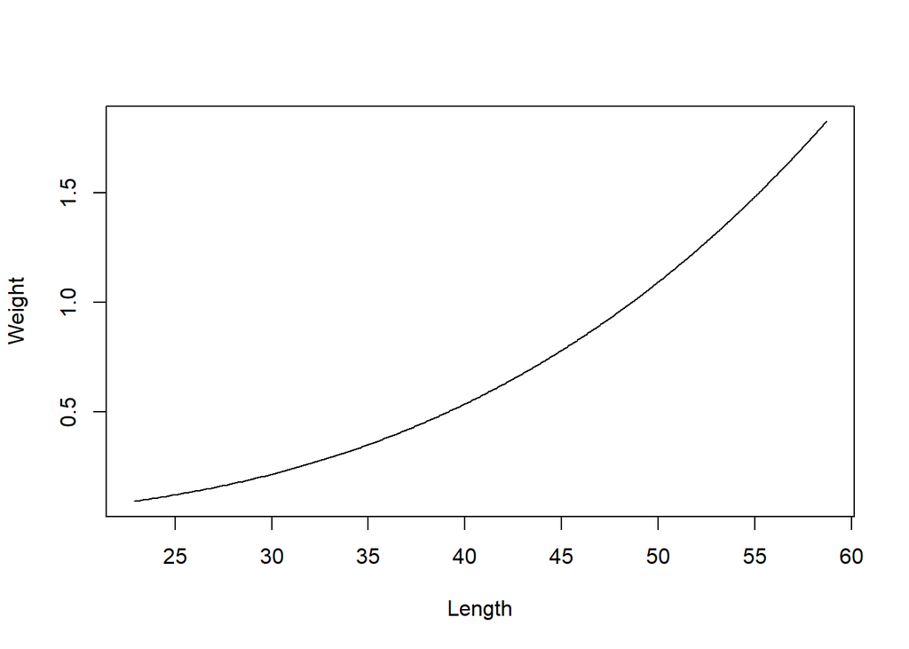

```r
## Plot length weight relationship
plot(ls,ws,type="l",xlab="Length",ylab="Weight")
```

while plotting `ws` against `ages` shows weight at age relationship induced by the punctuated growth

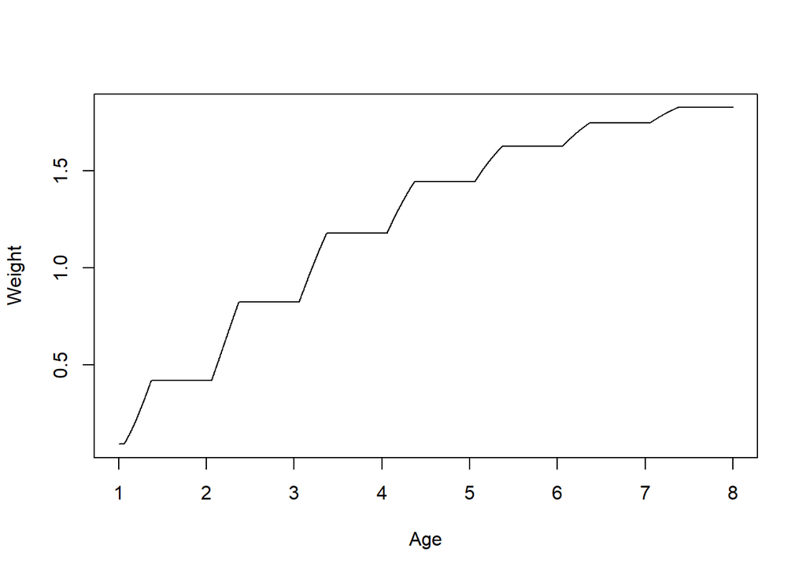

```r
## Plot weight at age
plot(ages,ws,type="l",xlab="Age",ylab="Weight")
```

Strictly, to perform a projection the model only *requires* the matrix `ws` of weight at ages, and the user is free to compute this matrix by any means, the only requirement being that it has one entry for each age class and each time point in the year. The matrices `ages` and `ls` are constructed purely for convenience.

## Mortality

The user must also provide several matrices that specify the fishing and natural mortality to be used in the projection.

The model decomposes both the fishing and natural mortalities into inter-annual and intra-annual components. So the fishing mortality is decomposed into an intra-annual component $f(a,t,y)$ and an annual scaling $F_{y}$ for that year. Similarly natural mortality is decomposed into the intra-annual component $m(a,t,y)$ and an annual scaling $M_{y}$. For a projection over a single year, $M_{y}$ and $F_{y}$ are just constants, while the intra-annual components are stored as matrices. The *unscaled* natural and fishing mortalities are the matrices

- `fs` - a matrix representing the intra-annual component of fishing mortality $f(a,t,y)$, and
- `ms` - a matrix representing the intra-annual component of natural mortality $m(a,t,y)$.

Scaling these matrices by $M_{y}$ and $F_{y}$ yields the *scaled* natural and fishing mortalities:

- `Ffs` - a matrix representing the total fishing mortality $F_{y} f(a,t,y)$, and
- `Mms` - a matrix representing the total natural mortality $M_{y} m(a,t,y)$.

- `Fs` - a matrix representing the unscaled integrated fishing mortality, and
- `Ms` - a matrix representing the unscaled integrated natural mortality,

while the *scaled integrated* mortalities are
$$F_{y} \int_{y}^{y+t} f(a,\tau,y) d \tau
\qquad \text{and} \qquad
M_{y} \int_{y}^{y+t} m(a,\tau,y) d \tau$$

and are represented by the matrices

- `FFs` - a matrix representing the scaled integrated fishing mortality, and
- `MMs` - a matrix representing the scaled integrated natural mortality.

All of the matrices described above have the same dimensions, with one column for each age class and one row for each time point. Any scaled matrix can be obtained from its unscaled counterpart by multiplying by $M_{y}$ and $F_{y}$ as appropriate. Any integrated quantity can be obtained from the corresponding non-integrated quantity with the `ctrapz` function, which implements the composite trapezoidal rule.

For some computations only the integration over the full year is relevant, and only the final row of the integrated mortalities are required. We define

- `Fsf` and `Msf` are the final rows of the unscaled integrated mortalities, and
- `FFsf` and `MMsf` are the final rows of the scaled integrated mortalities.

The relationships between these quantities are summarized in the following diagram

[interactive chart not shown]

Typically, the unscaled fishing mortality `fs` is determined by the fishing season and the gear selectivity.

In the krill assessment, selectivity is a function of length. The `rampOgive` function constructs a “linear ramp” from 0 to 1 with a given width and midpoint

```r
## Generate selectivity from length
ss <- rampOgive(ls,32,12)
head(ss)
```

```
##      [,1]      [,2] [,3] [,4] [,5] [,6] [,7]
## [1,]    0 0.9188689    1    1    1    1    1
## [2,]    0 0.9188689    1    1    1    1    1
## [3,]    0 0.9188689    1    1    1    1    1
## [4,]    0 0.9188689    1    1    1    1    1
## [5,]    0 0.9188689    1    1    1    1    1
## [6,]    0 0.9188689    1    1    1    1    1
```

Again, this matrix acts as a table that defines the selectivity for each age class and time point in the year, and we see that with these parameters, individuals of length less than 26mm are not selected and individuals of length greater than 38mm are fully selected.

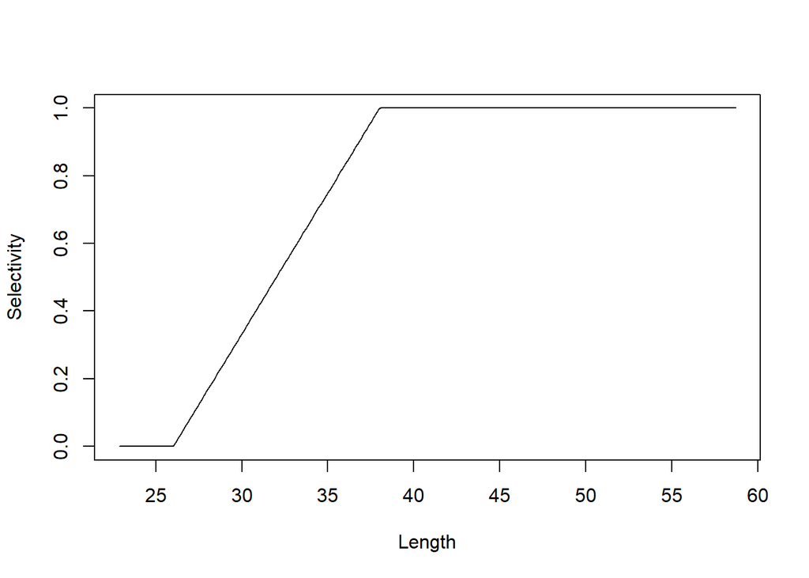

```r
plot(ls,ss,type="l",xlab="Length",ylab="Selectivity")
```

In this example selectivity has been computed as function of length, but it could equally well be calculated from age or weight using any appropriate functional relationship.

The selectivity is scaled by the distribution of effort within the year. If the fishing season spans the period from time point 31 to 200 within the year, we construct a vector that is zero for time points outside of the fishing season, and one at time points within

```r
fwy <- double(length=nsteps+1)
fwy[31:200] <- 1
```

and then rescale this so that the cumulative effort over the year is one

```r
## Within year fishing pattern
h <- 1/nsteps
fwy <- fwy/trapz(fwy,h)
```

The unscaled fishing mortality is the product of the selectivity and the distribution of effort within the year

```r
## Unscaled fishing mortality
fs <- fwy*ss
```

Again, this can be viewed as a table specifying the unscaled fishing effort for each age class and time point in the year.

Plotting the unscaled fishing effort against age shows that individuals are only exposed to fishing within the fishing season, and very young individuals are only partially selected

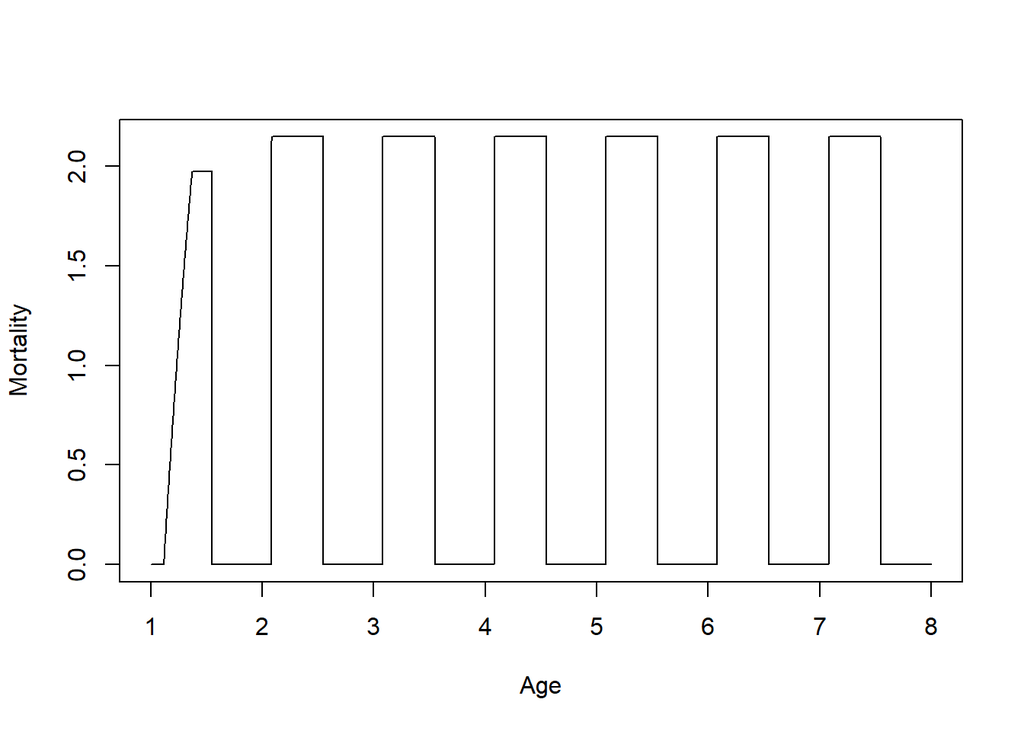

```r
## Plot unscaled fishing mortality
plot(ages,fs,type="l",xlab="Age",ylab="Mortality")
```

The unscaled integrated fishing mortality `Fs` is computed by integrating `fs` with `ctrapz`, and final row of the matrix is extracted with `final`

```r
## Unscaled integrated fishing mortality
Fs <- ctrapz(fs,h)
Fsf <- final(Fs)
```

This produces a table `Fs` of the cumulative (unscaled) fishing effort for each age class at each time point, and `Fsf` is simply the final row of this table, and corresponds to the total (unscaled) fishing effort expended in each age class.

The corresponding scaled quantities are obtained by scaling by the annual fishing mortality. Suppose we choose $F=0.2$, then

```r
## Scaled fishing mortalities
F <- 0.2
Ffs <- F*fs
FFs <- F*Fs
FFsf <- F*Fsf
```

The calculation of the natural mortalities is similar. It is common to assume natural mortality impacts all individuals of every age equally

```r
## Unscaled natural mortality
ms <- matrix(1,nsteps+1,length(Ages))
```

If we also assume an annual scaling $M=0.1$, then we can calculate all the associated mortalities as

```r
## Scaled Fishing mortality
M <- 0.1
Mms <- M*ms
## Integrated mortalities
Ms <- ctrapz(ms,h)
MMs <- ctrapz(Mms,h)
Msf <- final(Ms)
MMsf <- final(MMs)
```

## Projection

The `project` function projects forward over a year when the annual scaling `F` of the fishing mortality is known.

We must provide an initial age structure - the number of individuals in each age class at the start of the year. To illustrate, suppose the initial age structure is (this might be in units of millions of individuals)

```r
## Initial abundance
N0 <- seq(1,by=-0.1,length=length(Ages))
N0
```

```
## [1] 1.0 0.9 0.8 0.7 0.6 0.5 0.4
```

We then project forward by calling `project` with the weight at age matrix, scaled natural and fishing mortalities and the initial age structure

```r
## Project forward one year when F is known
pr <- project(ws, MMs, FFs, Ffs, N0)
```

This returns a list with elements

- `N` the matrix of the projected abundance (number of individuals) for each age class and time point
- `B` the matrix of the projected biomass for each age class and time point
- `Y` the matrix of the projected yield (ie cumulative catch) for each age class and time point

So for example, the matrix of project abundance has one column for each age class and one row for each time point, and the first row matches the initial age structure

```r
## Abundance
head(pr$N)
```

```
##           [,1]      [,2]      [,3]      [,4]      [,5]      [,6]      [,7]
## [1,] 1.0000000 0.9000000 0.8000000 0.7000000 0.6000000 0.5000000 0.4000000
## [2,] 0.9997261 0.8997535 0.7997809 0.6998082 0.5998356 0.4998630 0.3998904
## [3,] 0.9994522 0.8995070 0.7995618 0.6996165 0.5996713 0.4997261 0.3997809
## [4,] 0.9991784 0.8992606 0.7993427 0.6994249 0.5995071 0.4995892 0.3996714
## [5,] 0.9989047 0.8990142 0.7991238 0.6992333 0.5993428 0.4994524 0.3995619
## [6,] 0.9986311 0.8987680 0.7989049 0.6990418 0.5991786 0.4993155 0.3994524
```

Plotting the abundance of each age class over the year shows that the abundance can only decline, and the decline is more dramatic in the fishing season

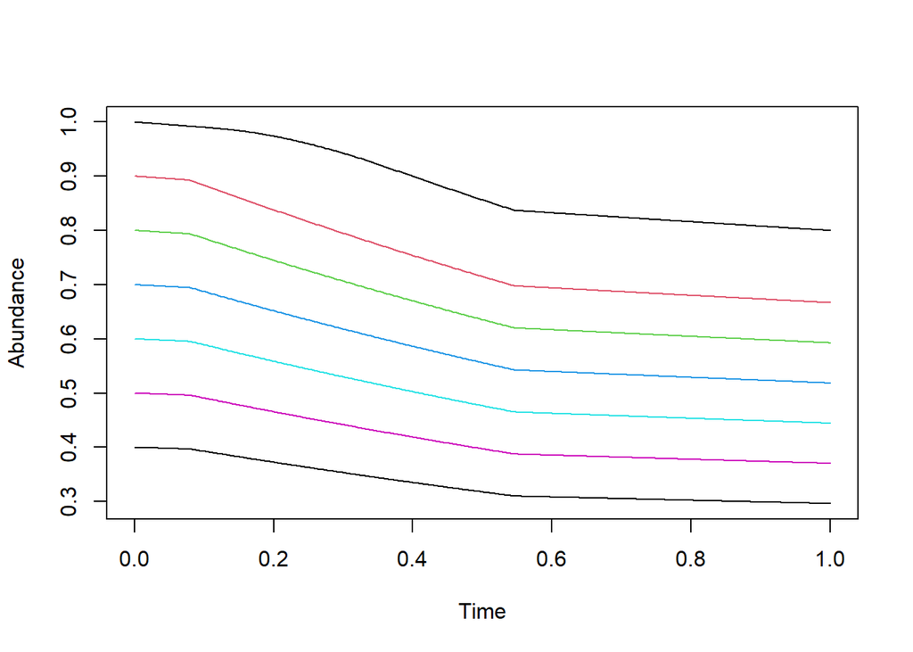

```r
## Abundance in each age class over the year
matplot(Days,pr$N,type="l",lty=1,xlab="Time",ylab="Abundance")
```

Plotting the biomass for each age class over the year shows although the abundance declines, the biomass of the stock can increase in the growth period

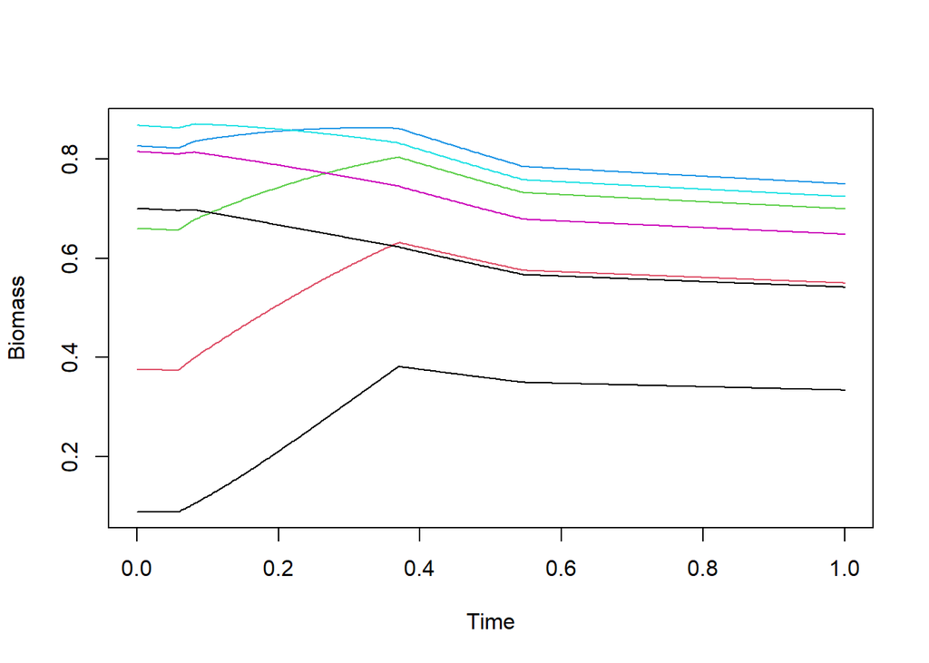

```r
## Biomass in each age class over the year
matplot(Days,pr$B,type="l",lty=1,xlab="Time",ylab="Biomass")
```

Plotting the yield shows the yield can only increase during the fishing season, and that the first age class is only weakly selected.

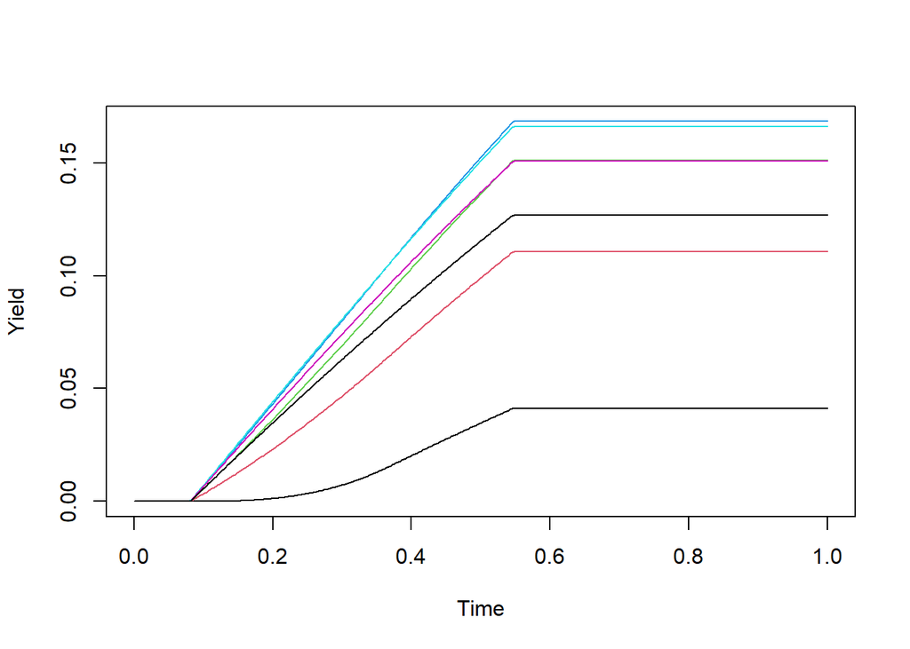

```r
## Yield in each age class over the year
matplot(Days,pr$Y,type="l",lty=1,xlab="Time",ylab="Yield")
```

The final row of the yield gives the total catch from each age class

```r
## Annual catch in each age class
final(pr$Y)
```

```
## [1] 0.04126697 0.11075249 0.15124482 0.16846389 0.16630719 0.15081949 0.12700601
```

Often the annual scaling of fishing mortality is not known, but the total catch is. The `projectC` function projects forward over a year when the total annual catch is known. In the previous example, $F=0.2$ and the total annual catch was

```r
## Total annual catch
C <- sum(final(pr$Y))
C
```

```
## [1] 0.9158609
```

When the target catch is known we project forward by calling `projectC` with the weight at age matrix, scaled natural mortality, the *unscaled* fishing mortalities, the target catch and the initial age structure

```r
## Project forward when annual catch is known
pr <- projectC(ws, MMs, Fs, fs, C, N0)
```

This the same projections of abundance, biomass and yield as before

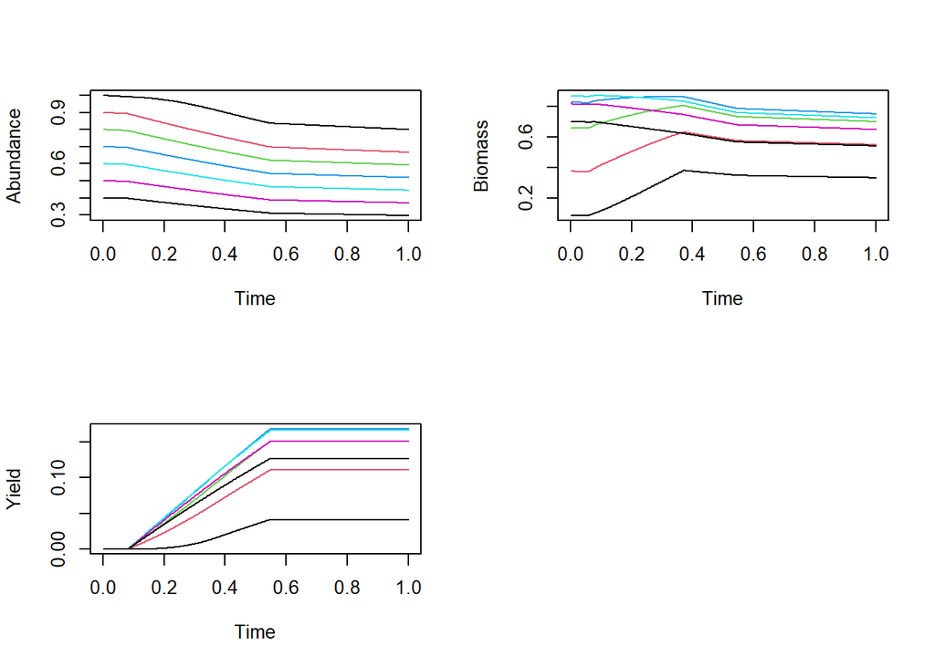

```r
## Abundance, biomass and yield over the year
opar <- par(mfrow=c(2,2))
matplot(Days,pr$N,type="l",lty=1,xlab="Time",ylab="Abundance")
matplot(Days,pr$B,type="l",lty=1,xlab="Time",ylab="Biomass")
matplot(Days,pr$Y,type="l",lty=1,xlab="Time",ylab="Yield")
par(opar)
```

together with an estimate of `F`

```r
## Estimated F
pr$F
```

```
## [1] 0.2
```

When the target catch is attainable, the projected total annual catch will match the prescribed target

```r
## Actual catch matches target
sum(final(pr$Y))
```

```
## [1] 0.9158609
```

But if the target catch is larger than the available biomass allows, the target is unattainable. When this occurs, `projectC` limits $F$ to an upper limit set by the argument `Fmax` and projects forward with this scaling

```r
## F is capped if target is unattainable
pr1 <- projectC(ws, MMs, Fs, fs, 10, N0, Fmax=2.5)
pr1$F
```

```
## [1] 2.5
```

The target catch is not attained

```r
## Catch is below the target
sum(final(pr1$Y))
```

```
## [1] 4.550688
```

and the stock becomes depleted to the point where fishing is ineffective

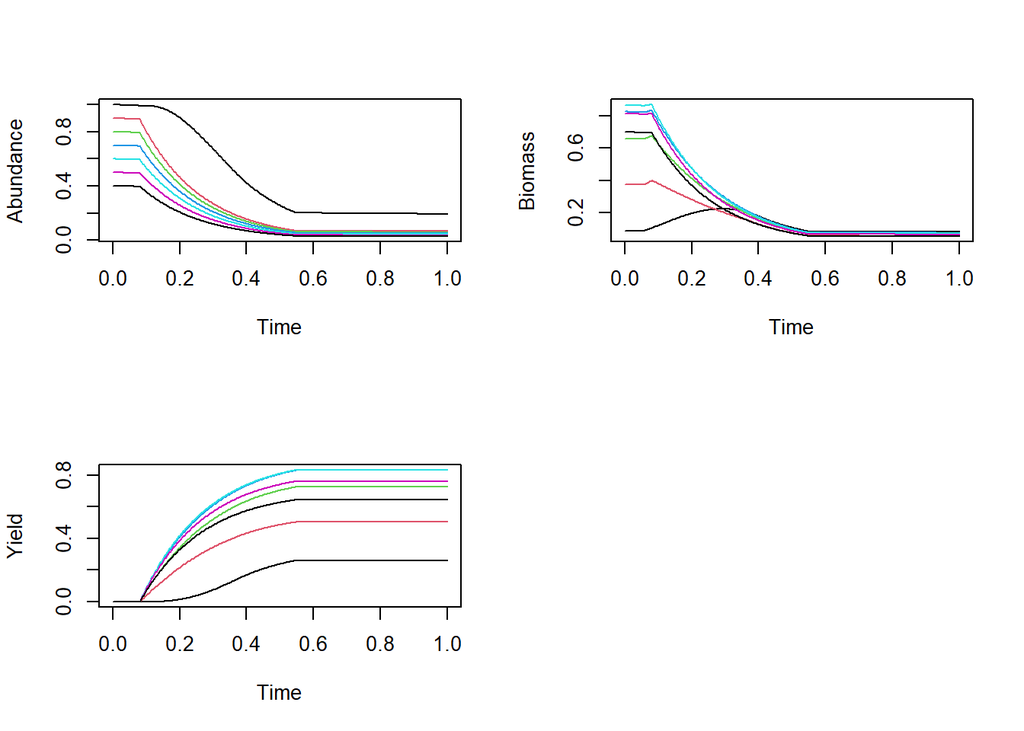

```r
## Stock is heavily depleted
opar <- par(mfrow=c(2,2))
matplot(Days,pr1$N,type="l",lty=1,xlab="Time",ylab="Abundance")
matplot(Days,pr1$B,type="l",lty=1,xlab="Time",ylab="Biomass")
matplot(Days,pr1$Y,type="l",lty=1,xlab="Time",ylab="Yield")
par(opar)
```

When using `projectC` it is important to check if the target has been attained by checking that `pr$F < Fmax`.

In the examples above, the projection is initialized by specifying the age structure at the beginning of the year, but both `project` and `projectC` offer more flexible initialization options. It is possible to specify the age structure at a time point other than the first with the `nref` argument

```r
## Set the abundance at time point 50
pr1 <- project(ws, MMs, FFs, Ffs, N0, nref=50)
pr1$N[50,]
```

```
## [1] 1.0 0.9 0.8 0.7 0.6 0.5 0.4
```

It is also possible to treat the initializing abundance as a relative abundance and scale the total abundance to reproduce a specified total biomass at some (possibly different) time point.

```r
## Set the relative abundance at time point 50, and the total biomass at time point 80
pr1 <- project(ws, MMs, FFs, Ffs, N0, nref=50, Bref=2, bref=80)
pr1$N[50,]/pr1$N[50,1]
```

```
## [1] 1.0 0.9 0.8 0.7 0.6 0.5 0.4
```

```r
sum(pr1$B[80,])
```

```
## [1] 2
```

## Stock Summaries

The `initial` and `final` functions extract the first and last row of a matrix

```r
## Initial abundance
initial(pr$N)
```

```
## [1] 1.0 0.9 0.8 0.7 0.6 0.5 0.4
```

```r
## Final abundance
final(pr$N)
```

```
## [1] 0.7998513 0.6667459 0.5926546 0.5185727 0.4444909 0.3704091 0.2963273
```

The `meanStock` function calculates the mean abundance or biomass in each age class over a specified time interval. To calculate mean abundance and biomass from time point 150 to time point 251

```r
## Monitoring period (time points)
period <- 150:251
## Mean abundance in each age class over the monitoring period
meanStock(pr$N, period=period)
```

```
## [1] 3.918275
```

```r
## Mean biomass in each age class over the monitoring period
meanStock(pr$B, period=period)
```

```
## [1] 4.511594
```

The `exploitableStock` function computes the mean abundance or biomass that is available to be exploited within in a given time period, and `vulnerableStock` computes the mean exploitable abundance or biomass weighted by fishing effort in the period.

To compute the exploitable and vulnerable biomass for the period from time point 150 to time point 251

```r
## Monitoring period
period <- 150:251
## Exploitable biomass
exploitableStock(pr$B, ss, period)
```

```
## [1] 4.482804
```

```r
## Vulnerable biomass
vulnerableStock(pr$B,ss,fwy,period)
```

```
## [1] 4.580477
```

To determine the spawning stock at some interval, we must construct a matrix `gs` that defines the fraction of individuals that are mature for each age class and time point in the year

```r
## Generate maturity from length
gs <- rampOgive(ls,36,6)
head(gs)
```

```
##      [,1]      [,2] [,3] [,4] [,5] [,6] [,7]
## [1,]    0 0.6710711    1    1    1    1    1
## [2,]    0 0.6710711    1    1    1    1    1
## [3,]    0 0.6710711    1    1    1    1    1
## [4,]    0 0.6710711    1    1    1    1    1
## [5,]    0 0.6710711    1    1    1    1    1
## [6,]    0 0.6710711    1    1    1    1    1
```

As before this acts as a table that gives the maturity of each age class at each time point in the year. For this example we have determined maturity as a function of length, but we could have calculated maturity as any appropriate function of age or weight.

The `spawningStock` function computes the mean mature abundance or biomass over a specified period

```r
## Spawning stock abundance
spawningStock(pr$N,gs,period=period)
```

```
## [1] 3.639106
```

```r
## Spawning stock biomass
spawningStock(pr$B,gs,period=period)
```

```
## [1] 4.394869
```

## Multiple Year Projections

Typically we will wish to project over multiple years. The `advance` function can be used to generate the starting abundance for the next year given the projected abundance for the current year and the number of recruits.

Project over the first year

```r
## Target catch
C <- 1
## Initial abundance
N0 <- seq(1,by=-0.1,length=length(Ages))
## Project forward first year
pr <- projectC(ws, MMs, Fs, fs, C, N0)
## Final abundance
final(pr$N)
```

```
## [1] 0.7897649 0.6531655 0.5805824 0.5080096 0.4354368 0.3628640 0.2902912
```

At this point in the script we would record appropriate summaries from the projection.

The `advance` function is then used to generate the initial abundance for the next year by progressing each age class by one year and inserting the recruits in the first age class

```r
## Number of recruits
R <- 1.1
## Advance individuals to next age class
N0 <- advance(pr$N,R)
N0
```

```
## [1] 1.1000000 0.7897649 0.6531655 0.5805824 0.5080096 0.4354368 0.3628640
```

and these abundances are used to initialize the next projection.

```r
## Project forward second year
pr <- projectC(ws, MMs, Fs, fs, C, N0)
```

The repeated use of `project` or `projectC` will typically be the core of an assessment script. There are two important things to consider.

Typically an assessment will project forward over multiple years with code something like the following

```r
### Setup code ###
for(yr in years) {

  ## Project forward
  pr <- project(...)

  ### Collect results from this projection ###

  ## Set age structure for next projection
  N0 <- advance(pr$N,R)
}
```

R uses a technique called “copy-on-write” to minimize memory usage (discussed in detail in (Advanced R)[https://adv-r.hadley.nz/names-values.html] and this (blog post)[https://www.brodieg.com/2019/02/18/an-unofficial-reference-for-internal-inspect/]). Typically, this means that using `dataframe` to collect results from successive projections will lead to a great deal of unnecessary copying and is extremely inefficient, but using a matrix to collect results often will not force a copy and is much more efficient. As a general guide

- within loops, prefer collecting results in vectors, matrices or arrays, and
- where possible, calculated any derived quantities outside the loop.

These issues can be very difficult to debug, particularly when working interactively in RStudio or the debugger, as both these tools monitor R’s internal state and this can change the way copying occurs.

Depending on the model assumptions, any or all of the model parameters may vary annually and so it may be necessary to recalculate the input matrices (tables) between calls to the project functions. The project functions have been designed to allow the user to minimize the amount of recalculation, but it is the users responsibility to manage this issue.

So for example, we could avoid calculating many of the mortality matrices by replacing `projectC` with the function

```r
project1 <- function(ws,ss,M,C,N0,nsteps=365,nages=length(Ages)) {

  h <- 1/nsteps
  fwy <- double(length=nsteps+1)
  fwy[31:200] <- 1
  fwy <- fwy/trapz(fwy,h)
  fs <- fwy*ss
  Fs <- ctrapz(fs,h)
  ms <- matrix(1,nsteps+1,nages)
  MMs <- ctrapz(M*ms,h)
  projectC(ws, MMs, Fs, fs, C, N0)
}
```

But this would unnecessarily recompute the mortality matrices for every projection.

## Initial Age Structure

The `ageStructureS` and `ageStructureD` functions generate initial age structures from which to start the first projection. Essentially these functions perform a sequence of annual projections of abundance to determine an “equilibrium” age structure.

The `ageStructureD` function generates an initial age structure deterministically assuming the number of recruits has remained exactly constant throughout history

```r
## Generate deterministic age structure
N0 <- ageStructureD(MMsf,R=1)
N0
```

```
## [1] 1.0000000 0.9048374 0.8187308 0.7408182 0.6703200 0.6065307 0.5488116
```

The `ageStructureS` function generates an initial age structure stochastically given a vector of random recruits. The vector of recruits must be at least as long as the number of age classes.

```r
## Random recruits
R <- rlnorm(10,0,1)
## Generate stochastic age structure
N0 <- ageStructureS(R,Msf,M)
N0
```

```
## [1] 0.3671861 2.0030248 0.4229180 0.1633310 0.4548489 1.7331113 1.1665690
```

This generates a different age structure for each new random vector of recruits

```r
## Random recruits
R <- rlnorm(10,0,1)
## Generate stochastic age structure
N0 <- ageStructureS(R,Msf,M)
N0
```

```
## [1] 0.16551885 0.97107129 0.90533090 0.05745849 0.33465324 0.12149712 0.11011898
```

## Virgin Spawning Stock Biomass

The virgin spawning stock biomass $B_{0}$ (that is, the biomass of the spawning stock at equilibrium in the absence of fishing) is often used as a reference value against which to estimate depletion of the stock.

The `spawningB0D` function estimates $B0$ by deterministically computing an initial age structure and projecting forward one year to compute spawning stock biomass.

```r
## Time points in the spawning period
spawn <- 201:281
## Virgin spawning stock abundance
spawningB0D(gs=gs, ws=ws, MMs=M*Ms, spawn=spawn)
```

```
## [1] 5.824236
```

The `spawningB0S` function estimates $B0$ by simulating many initial age structures and projecting each forward one year to compute spawning stock biomass, then computing the median, mean and standard deviations of the simulated spawning stock biomasses.

In this case we must provide a matrix of random recruit numbers - the number of columns determines the number of years to simulate and the number of rows determines the number of simulations.

```r
## Time points in the spawning period
spawn <- 201:281
## Matrix of 1000 random recruitment vectors
R <- matrix( rlnorm(10000,0,1),nrow=1000,ncol=10)
## Virgin spawning stock abundance
spawningB0S(R, gs, ws, Ms, M, spawn)
```

```
## $median
## [1] 8.729058
##
## $mean
## [1] 9.791436
##
## $sd
## [1] 5.581204
##
## $n
## [1] 1000
```

Even with a 1000 simulations, the mean and median are poorly estimated.

```r
## Matrix of 1000 random recruitment vectors
R <- matrix( rlnorm(10000,0,1),nrow=1000,ncol=10)
## Virgin spawning stock abundance
spawningB0S(R, gs, ws, Ms, M, spawn)
```

```
## $median
## [1] 8.826591
##
## $mean
## [1] 10.11604
##
## $sd
## [1] 5.123075
##
## $n
## [1] 1000
```

## Recruitment

Grym implements several of methods for simulating the number of individuals recruited to the fishery in a year. These are methods are discussed in Pavez et al. (n.d.) and de la Mare (1994).

In principle, the number of recruits can be drawn from any suitable distribution.

Here we focus on the methods used in the current krill assessment. de la Mare (1994) proposed a “proportional recruitment” method that estimates both the annual scaling of natural mortality $M$ and the recruitment variability given the mean and variance of the fraction of the population that are recruits, estimated from independent surveys. However, Pavez et al. (n.d.) showed that the method proposed by de la Mare (1994) can be unreliable when recruitment variability is large, and proposed a more robust alternative and that method is used in the current krill assessment.

The krill assessment pre-generates recruitment sequences for the projections, and re-uses the same recruitment sequences across different parameter scenarios to permit a more direct comparison of alternate scenarios.

Let the proportion $R$ denote the fraction that a given reference age class is of the population of all age classes of the same age or older.

The method estimates distributional parameters from the mean and variance of $R$ observed in surveys. The method generates a sequence of uniform random deviates, and applies a [probability integral transform](https://en.wikipedia.org/wiki/Probability_integral_transform) to transform these deviates to deviates from the desired distributional family. These deviates are use to simulate the proportion of the reference class that would be seen in the surveys, and the parameters of the probability integral transform are adjusted to match the mean and variance observed in the surveys. Not every sequence of uniform deviates can be transformed to adequately match the observed mean and variance, and so in some cases the sequence must be discarded and a new sequence generated.

The `prFit1` function takes as arguments

- `qdist` - the quantile function of the target distribution parameterized in terms of the mean and variance.
- `Msf` - the final row of the unscaled integrated natural mortality
- `mnR`, `vrR` - the target mean and variance of $R$ estimated from `n` independent surveys
- `M0`, `CV0` - initial estimates of the natural mortality and recruitment variability (coefficient of variation)
- `r` - the reference age class used to generate the proportion $R$.

The `prFit1` function first generates sequence of uniform deviates `us`. The `err` function uses the total mortalities `Msf`, to simulate the proportion `R` that would be seen in `n` surveys, and hence the sum of the squared error in the simulated mean and variance of `R`. This function is used by `optim` to determine the parameters of the probability integral transform that give the best match to the observed mean and variance. The function then checks the estimated parameters reproduce the mean and variance to within the desired tolerance, and if so return these parameters together with the mean and variance of $Q = R/(1-R)$ (which is needed for the subsequent simulation), otherwise the function returns `NULL`.

```r
prFit1 <- function(qdist,Msf,mnR,vrR,n,M0,CV0,r=1,plus=0,rstdunif=runif,tol=1.0E-4,max.M=10,max.CV=10) {
  ## Generate deviates
  us <- rstdunif(n*(1-r+length(Msf)+plus))

  err <- function(par) {
    ## Compute survivals
    S <- exp(-par[1]*Msf)
    S <- cumprod(c(S[-length(S)],rep(S[length(S)],plus)))
    s0 <- sum(S)
    S <- c(1,S)
    if(r>1) S <- S[r:length(S)]

    ## Mean and variance of Q
    mnQ <- 1/s0
    vrQ <- (par[2]*mnQ)^2
    ## Simulate
    A <- matrix(s0*qdist(us,mnQ,vrQ),length(S))
    N <- S*A
    R <- N[1,]/colSums(N)
    (mnR-mean(R,na.rm=TRUE))^2+(sqrt(vrR)-sd(R,na.rm=TRUE))^2
  }

  ## Fit the model
  fit <- tryCatch(optim(c(M=M0,CV=CV0),fn=err,method="L-BFGS-B",lower=c(0,0),upper=c(max.M,max.CV)),
                  error=function(.) NULL, warning=function(.) NULL)

  ## Recompute parameters
  if(!is.null(fit) && fit$value < tol && fit$par[1] < max.M && fit$par[2] < max.CV) {
    par <- unname(fit$par)
    ## Compute survivals
    S <- exp(-par[1]*Msf)
    S <- cumprod(c(S[-length(S)],rep(S[length(S)],plus)))
    s0 <- sum(S)
    S <- c(1,S)
    if(r>1) S <- S[r:length(S)]

    ## Mean and variance of Q
    mnQ <- 1/s0
    vrQ <- (par[2]*mnQ)^2
    c(M=par[1],CV=par[2],mnQ=mnQ,vrQ=vrQ)
  }
}
```

The `prFit` functions repeatedly calls `prFit1`, restarting with a new sequence of random deviates if `prFit1` fails. If `max.iter` is not set, this function may never return.

```r
prFit <- function(qdist,Msf,mnR,vrR,n,M0,CV0,r=1,plus=0,rstdunif=runif,tol=1.0E-6,max.M=10,max.CV=10,max.iter=Inf) {
  k <- 1
  repeat {
    k <- k+1
    fit <- prFit1(qdist,Msf,mnR,vrR,n,M0,CV0,r,plus,rstdunif,tol,max.M,max.CV)
    if(!is.null(fit) | k>max.iter) return(fit)
  }
}
```

To generate gamma distributed deviates, we must supply the Gamma quantile function parameterized in terms of the mean and variance of the Gamma distribution.

```r
## Gamma quantile function
qGamma <- function(us,mn,vr) suppressWarnings(qgamma(us,mn^2/vr,mn/vr))
```

Then if the reference age class used to generate $R$ is the second age class (ie $R$ is the fraction that the second age class is of the population of age class 2 and older), and the values for mean and variance of $R$ estimated from 10 surveys are

```r
## Survey parameters
R.class <- 2
R.mean <- 0.2
R.var <- (0.04)^2
R.nsurveys <- 10
```

Then we can estimate a suitable set of recruitment parameters with

```r
## Estimate distributional parameters
M0 <- 0.1
CV0 <- 0.2
ps <- prFit(qGamma,Msf,R.mean,R.var,R.nsurveys,M0,CV0,R.class)
ps
```

```
##            M           CV          mnQ          vrQ
## 0.0571141399 0.1414010492 0.2025816379 0.0008205507
```

Given these parameters, a new recruitment sequence can be generated with

```r
## Function to generate recruits
recGamma <- function(n,mn,vr) rgamma(n,mn^2/vr,mn/vr)/mn
```

This will generate random sequences of recruits with mean 1 and the correct coefficient of variation

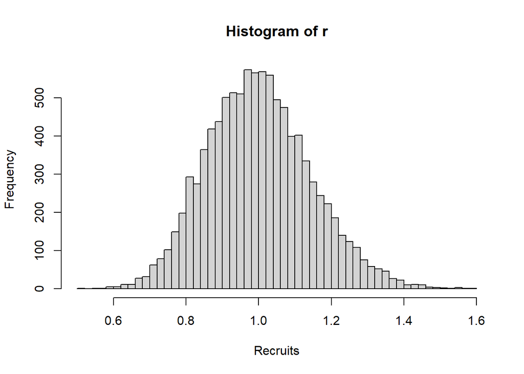

```r
## Recruits are Gamma distributed
r <- recGamma(10000,ps[3],ps[4])
hist(r,50,xlab="Recruits")
```

```r
mean(r)
```

```
## [1] 1.001187
```

```r
sd(r)
```

```
## [1] 0.1425305
```

If we base the simulations on correlated uniform deviates (generated with Gaussian copulas)

```r
## Correlated uniform random deviates
rcunif <- function(n,rho) {
  if(rho==0)
    runif(n)
  else
    pnorm(sqrt(1-rho^2)*as.vector(arima.sim(list(ar=rho),n)))
}
## Recruitment function
rcRec <- function(n,mn,vr,rho=0) {
  qGamma(rcunif(n,rho),mn,vr)/mn
}
```

```r
## Estimate distributional parameters
M0 <- 0.1
CV0 <- 0.2
rho <- 0.7
ps <- prFit(qGamma,Msf,R.mean,R.var,R.nsurveys,M0,CV0,R.class,rstdunif=function(n) rcunif(n,rho))
ps
```

```
##          M         CV        mnQ        vrQ
## 0.10550214 0.47013475 0.23724097 0.01244011
```

The simulated numbers of recruits are still Gamma distributed

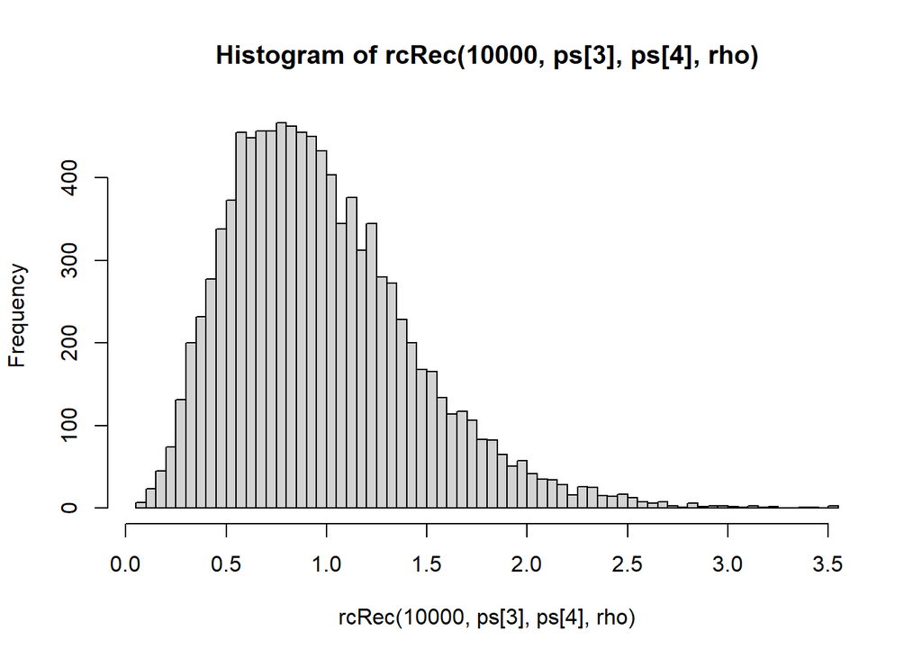

```r
## Recruitment is Gamma distributed
hist(rcRec(10000,ps[3],ps[4],rho),50)
```

but numbers of recruits in successive years are correlated

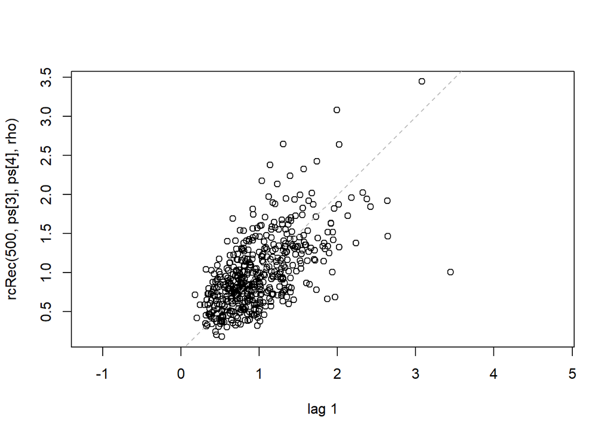

```r
## Numbers of recruits are correlated
lag.plot(rcRec(500,ps[3],ps[4],rho),lag=1)
```

## References

Constable, AJ, and WK de la Mare. 1996. “A Generalised Model for Evaluating Yield and the Long-Term Status of Fish Stocks Under Conditions of Uncertainty.” *CCAMLR Science* 3: 31–54.

de la Mare, WK. 1994. “Modelling Krill Recruitment.” *CCAMLR Science* 1: 49–54.

Pavez, C., S. Wotherspoon, D. Maschette, K. Reid, and K. Swadling. n.d. *Recruitment Modelling for Euphausia Superba Stock Assessments Considering the Recurrence of Years with Low Recruitment*. WG-SAM-2021/09. Commission for the Conservation of Antarctic Marine Living Resources.